# Biostat776_Project_2

Can Wang

2024-09-23

# Part 1: Fun with functions

### Part 1A: Exponential transformation

```r
Exp <- function(x, k) {
    sum <- 1
    for(i in 1:k){
      sum <- sum + x^i/factorial(i)
    }
    return(sum)
}
Exp(5,100)
```

```
## [1] 148.4132
```

### Part 1B: Sample mean and sample standard deviation

```r
sample_mean <- function(x) {
  sum <- 0
  N <- length(x)
  for(i in 1:N){
    sum <- sum + x[i]
  }
  return(sum/N)
}

sample_sd <- function(x) {
    sum <- 0
    N <- length(x)
    for(i in 1:N){
      sum <- sum + (x[i]-sample_mean(x))^2
    }
    return(sqrt(sum/(N-1)))
}

x <- c(1,2,3,4,5,6,7,8,9,10)
print(sample_mean(x))
```

```
## [1] 5.5
```

```r
print(sample_sd(x))
```

```
## [1] 3.02765
```

### Part 1C: Confidence intervals

```r
calculate_CI <- function(x, conf = 0.95) {
    alpha <- 1 - conf
    N <- length(x)
    degrees_freedom <- N - 1
    t_score <- qt(p = alpha / 2, df = degrees_freedom, lower.tail = FALSE)
    lower_bound <- mean(x) - t_score*(sd(x)/sqrt(N))
    upper_bound <- mean(x) + t_score*(sd(x)/sqrt(N))
    CI <- c(lower_bound,upper_bound)
    return(CI)
}
calculate_CI(x,conf = 0.95)
```

```
## [1] 3.334149 7.665851
```

```r
calculate_CI(x,conf = 0.90)
```

```
## [1] 3.744928 7.255072
```

```r
## Compare with existing function
dat <- data.frame(x = x)
fit <- lm(x ~ 1, dat)
confint(fit, level = 0.95)
```

```
##                2.5 %   97.5 %
## (Intercept) 3.334149 7.665851
```

```r
confint(fit, level = 0.90)
```

```
##                  5 %     95 %
## (Intercept) 3.744928 7.255072
```

# Part 2: Wrangling data

### Data

```r
library(here)
if (!file.exists(here("data", "tuesdata_rainfall.RDS"))) {
    tuesdata <- tidytuesdayR::tt_load("2020-01-07")
    rainfall <- tuesdata$rainfall
    temperature <- tuesdata$temperature

    # save the files to RDS objects
    saveRDS(tuesdata$rainfall, file = here("data", "tuesdata_rainfall.RDS"))
    saveRDS(tuesdata$temperature, file = here("data", "tuesdata_temperature.RDS"))
}
rainfall <- readRDS(here("data", "tuesdata_rainfall.RDS"))
temperature <- readRDS(here("data", "tuesdata_temperature.RDS"))
library(tidyverse)
glimpse(rainfall)
```

```
## Rows: 179,273
## Columns: 11
## $ station_code <chr> "009151", "009151", "009151", "009151", "009151", "009151…
## $ city_name    <chr> "Perth", "Perth", "Perth", "Perth", "Perth", "Perth", "Pe…
## $ year         <dbl> 1967, 1967, 1967, 1967, 1967, 1967, 1967, 1967, 1967, 196…
## $ month        <chr> "01", "01", "01", "01", "01", "01", "01", "01", "01", "01…
## $ day          <chr> "01", "02", "03", "04", "05", "06", "07", "08", "09", "10…
## $ rainfall     <dbl> NA, NA, NA, NA, NA, NA, NA, NA, NA, NA, NA, NA, NA, NA, N…
## $ period       <dbl> NA, NA, NA, NA, NA, NA, NA, NA, NA, NA, NA, NA, NA, NA, N…
## $ quality      <chr> NA, NA, NA, NA, NA, NA, NA, NA, NA, NA, NA, NA, NA, NA, N…
## $ lat          <dbl> -31.96, -31.96, -31.96, -31.96, -31.96, -31.96, -31.96, -…
## $ long         <dbl> 115.79, 115.79, 115.79, 115.79, 115.79, 115.79, 115.79, 1…
## $ station_name <chr> "Subiaco Wastewater Treatment Plant", "Subiaco Wastewater…
```

```r
glimpse(temperature)
```

```
## Rows: 528,278
## Columns: 5
## $ city_name   <chr> "PERTH", "PERTH", "PERTH", "PERTH", "PERTH", "PERTH", "PER…
## $ date        <date> 1910-01-01, 1910-01-02, 1910-01-03, 1910-01-04, 1910-01-0…
## $ temperature <dbl> 26.7, 27.0, 27.5, 24.0, 24.8, 24.4, 25.3, 28.0, 32.6, 35.9…
## $ temp_type   <chr> "max", "max", "max", "max", "max", "max", "max", "max", "m…
## $ site_name   <chr> "PERTH AIRPORT", "PERTH AIRPORT", "PERTH AIRPORT", "PERTH …
```

### 1. Start with rainfall dataset and drop any rows with NAs.

```r
rainfall_omit <- na.omit(rainfall)
```

### 2. Create a new column titled date that combines the columns year, month, day into one column separated by “-”. (e.g. “2020-01-01”). This column should not be a character, but should be recognized as a date.

```r
rainfall_omit$date <- ymd(paste(rainfall_omit$year, rainfall_omit$month, rainfall_omit$day, sep = "-"))
```

### 3. Using the city_name column, convert the city names (character strings) to all upper case.

```r
rainfall_omit$city_name <- str_to_upper(rainfall_omit$city_name)
glimpse(rainfall_omit)
```

```
## Rows: 64,476
## Columns: 12
## $ station_code <chr> "009151", "009151", "009151", "009151", "009151", "009151…
## $ city_name    <chr> "PERTH", "PERTH", "PERTH", "PERTH", "PERTH", "PERTH", "PE…
## $ year         <dbl> 1967, 1967, 1967, 1967, 1967, 1967, 1967, 1967, 1967, 196…
## $ month        <chr> "07", "07", "07", "07", "07", "07", "07", "07", "07", "07…
## $ day          <chr> "05", "06", "07", "10", "11", "14", "15", "16", "17", "18…
## $ rainfall     <dbl> 2.8, 4.8, 5.8, 16.0, 1.0, 1.0, 15.5, 8.6, 12.2, 6.1, 11.7…
## $ period       <dbl> 1, 1, 1, 1, 1, 1, 1, 1, 1, 1, 1, 1, 1, 1, 1, 1, 1, 1, 1, …
## $ quality      <chr> "Y", "Y", "Y", "Y", "Y", "Y", "Y", "Y", "Y", "Y", "Y", "Y…
## $ lat          <dbl> -31.96, -31.96, -31.96, -31.96, -31.96, -31.96, -31.96, -…
## $ long         <dbl> 115.79, 115.79, 115.79, 115.79, 115.79, 115.79, 115.79, 1…
## $ station_name <chr> "Subiaco Wastewater Treatment Plant", "Subiaco Wastewater…
## $ date         <date> 1967-07-05, 1967-07-06, 1967-07-07, 1967-07-10, 1967-07-…
```

### 4. Join this wrangled rainfall dataset with the temperature dataset such that it includes only observations that are in both data frames. (Hint: there are two keys that you will need to join the two datasets together).

```r
df <- inner_join(rainfall_omit, temperature, by = c("city_name", "date"))
glimpse(df)
```

```
## Rows: 83,964
## Columns: 15
## $ station_code <chr> "009151", "009151", "009151", "009151", "009151", "009151…
## $ city_name    <chr> "PERTH", "PERTH", "PERTH", "PERTH", "PERTH", "PERTH", "PE…
## $ year         <dbl> 1967, 1967, 1967, 1967, 1967, 1967, 1967, 1967, 1967, 196…
## $ month        <chr> "07", "07", "07", "07", "07", "07", "07", "07", "07", "07…
## $ day          <chr> "05", "05", "06", "06", "07", "07", "10", "10", "11", "11…
## $ rainfall     <dbl> 2.8, 2.8, 4.8, 4.8, 5.8, 5.8, 16.0, 16.0, 1.0, 1.0, 1.0, …
## $ period       <dbl> 1, 1, 1, 1, 1, 1, 1, 1, 1, 1, 1, 1, 1, 1, 1, 1, 1, 1, 1, …
## $ quality      <chr> "Y", "Y", "Y", "Y", "Y", "Y", "Y", "Y", "Y", "Y", "Y", "Y…
## $ lat          <dbl> -31.96, -31.96, -31.96, -31.96, -31.96, -31.96, -31.96, -…
## $ long         <dbl> 115.79, 115.79, 115.79, 115.79, 115.79, 115.79, 115.79, 1…
## $ station_name <chr> "Subiaco Wastewater Treatment Plant", "Subiaco Wastewater…
## $ date         <date> 1967-07-05, 1967-07-05, 1967-07-06, 1967-07-06, 1967-07-…
## $ temperature  <dbl> 17.8, 8.7, 18.4, 8.0, 17.2, 10.5, 16.1, 4.4, 16.8, 4.1, 2…
## $ temp_type    <chr> "max", "min", "max", "min", "max", "min", "max", "min", "…
## $ site_name    <chr> "PERTH AIRPORT", "PERTH AIRPORT", "PERTH AIRPORT", "PERTH…
```

# Part 3: Data visualization

### Part 3A: Plotting temperature data over time

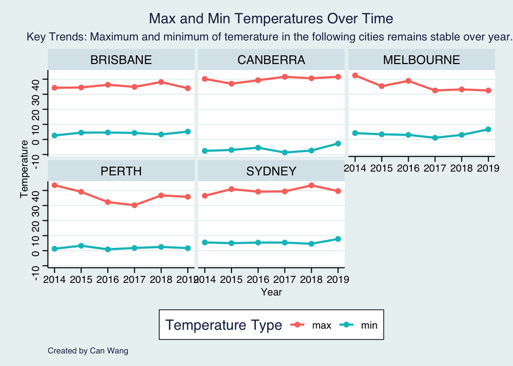

```r
df_3a <- df[c('city_name','year','temperature')]
df_3a <- df_3a[df_3a$year>=2014,]
df_3a_plot <- df_3a%>%
  group_by(city_name,year)%>%
  summarise(max=max(temperature,na.rm = TRUE),min=min(temperature,na.rm = TRUE),.groups = 'drop')


df_3a_plot_long <- df_3a_plot %>%
  pivot_longer(cols = c(max, min),
               names_to = "temperature_type",
               values_to = "temperature")

ggplot(df_3a_plot_long, aes(x = year, y = temperature, color = temperature_type)) +
  ggthemes::theme_stata()+
  geom_line(size = 1) +
  geom_point(size = 2) +
  labs(title = "Max and Min Temperatures Over Time",
       x = "Year",
       y = "Temperature",
       color = "Temperature Type") +
  facet_wrap(~ city_name) +
  labs(subtitle="Key Trends: Maximum and minimum of temerature in the following cities remains stable over year. ",caption = "Created by Can Wang")
```

### Part 3B: Plotting rainfall over time

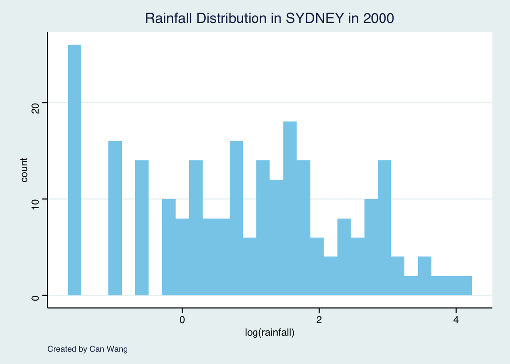

```r
plot_rainfall <- function(p_city, p_year){
  filtered_data <- df %>%
    filter(city_name == p_city, year == p_year)

  if (nrow(filtered_data) == 0) {
    stop(paste("Error: No data found for city:", p_city, "and year:", p_year))
  }

  ggplot(filtered_data, aes(log(rainfall))) +
    ggthemes::theme_stata() +
    geom_histogram(fill = "skyblue") +
    labs(title = paste("Rainfall Distribution in", p_city, "in", p_year),caption="Created by Can Wang")
}

plot_rainfall("SYDNEY", 2000)
```

Description: In the function plot_rainfall, there are two parameters, which are p_city (the city name) and p_year (the year). The user input the two parameters, and the function returns the histogram of log-rainfall of that particular city and year. In the function, we first filter the data by city_name and year. Then we check if the data exist. If not, use stop() to report this error. Otherwise, we then plot the histogram. The plot includes a title indicating the parameters, as well as informative x-axis and y-axis labels.

# Part 4: Apply functions and plot

### Part 4A: Apply the functions we wrote in Part 1 to our rainfall data starting with our wrangled df data from Part 2

```r
## First, filter for only years including 2014 and onwards.
df_4a <- df[df$year>=2014,]
## For a given city and for a given year, calculate the sample mean (using your function sample_mean()), the sample standard deviation (using your function sample_sd()), and a 95% confidence interval for the average rainfall (using your function calculate_CI()). Specifically, you should add two columns in this summarized dataset: a column titled lower_bound and a column titled upper_bound containing the lower and upper bounds for you CI that you calculated (using your function calculate_CI()).
rain_df <- df_4a %>%
  group_by(city_name,year)%>%
  summarise(mean_rainfall=sample_mean(rainfall),
            sd_rainfall=sample_sd(rainfall),
            lower_bound=calculate_CI(rainfall)[1],
            upper_bound=calculate_CI(rainfall)[2])
rain_df
```

```
## # A tibble: 30 × 6
## # Groups:   city_name [5]
##    city_name  year mean_rainfall sd_rainfall lower_bound upper_bound
##    <chr>     <dbl>         <dbl>       <dbl>       <dbl>       <dbl>
##  1 BRISBANE   2014          3.84       12.3         2.99        4.69
##  2 BRISBANE   2015          6.17       22.7         4.53        7.82
##  3 BRISBANE   2016          2.09        8.61        1.47        2.72
##  4 BRISBANE   2017          2.72       10.2         1.97        3.47
##  5 BRISBANE   2018          2.47        9.63        1.75        3.19
##  6 BRISBANE   2019          2.10        6.35        1.38        2.82
##  7 CANBERRA   2014          1.57        4.84        1.22        1.92
##  8 CANBERRA   2015          1.51        5.16        1.13        1.89
##  9 CANBERRA   2016          2.15        6.28        1.70        2.61
## 10 CANBERRA   2017          1.34        4.12        1.04        1.64
## # ℹ 20 more rows
```

### Part 4B: Using the rain_df, plots the estimates of mean rainfall and the 95% confidence intervals on the same plot. There should be a separate faceted plot for each city.

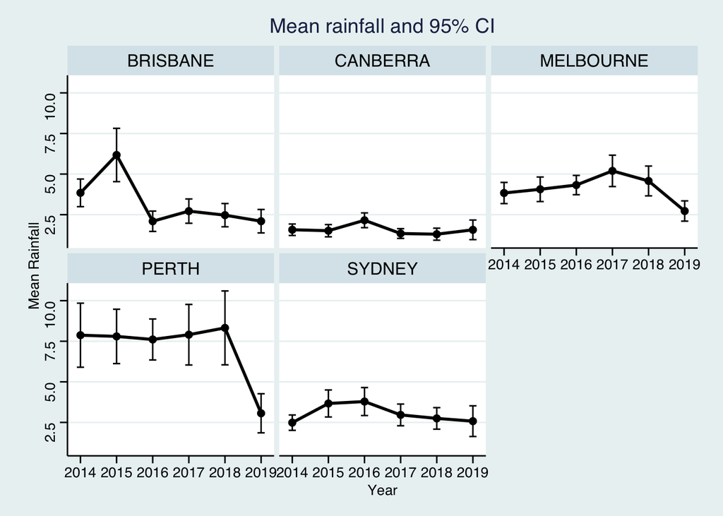

```r
ggplot(rain_df, aes(x = year, y = mean_rainfall)) +
  ggthemes::theme_stata()+
  geom_line(size = 1) +
  geom_point(size = 2) +
  geom_errorbar(aes(ymin = lower_bound, ymax = upper_bound), width = 0.2)+
  labs(title = "Mean rainfall and 95% CI",
       x = "Year",
       y = "Mean Rainfall") +
  facet_wrap(~ city_name)
```